# Trabajo final: Explorando Datos con R

Emanuel Farcy

2024-02-04

# Introducción

En este trabajo nos proponemos explorar un dataset de una empresa de jardinería. El dataset contiene información sobre los clientes de la empresa y vamos a analizar la relación entre el límite de crédito, el país y la región de los clientes.

Tomamos estas tres variables para nuestro análisis porque consideramos que son las más relevantes para la empresa. El límite de crédito es importante porque le permite saber cuánto crédito puede otorgar a cada cliente. El país y la región son importantes porque la empresa de jardinería puede tener diferentes estrategias de marketing y ventas para cada país y región.

Por estas razones la conexión entre ellas está justificada y es el objetivo de nuestro análisis ya que nos permitirá entender mejor a los clientes de la empresa, los contextos en los que se encuentran y cómo la empresa puede adaptar sus estrategias a cada contexto.

```
## -- Visualización de los clientes data frame Jardinería--
```

|  | codigo_cliente | nombre_cliente | nombre_contacto | apellido_contacto | telefono | fax | linea_direccion1 | linea_direccion2 | ciudad | region | pais | codigo_postal | codigo_empleado_rep_ventas | limite_credito |
| --- | --- | --- | --- | --- | --- | --- | --- | --- | --- | --- | --- | --- | --- | --- |
| 1 | 1 | GoldFish Garden | Daniel G | GoldFish | 5556901745 | 5556901746 | False Street 52 2 A | NULL | San Francisco | NULL | USA | 24006 | 19 | 3000 |
| 2 | 3 | Gardening Associates | Anne | Wright | 5557410345 | 5557410346 | Wall-e Avenue | NULL | Miami | Miami | USA | 24010 | 19 | 6000 |
| 3 | 4 | Gerudo Valley | Link | Flaute | 5552323129 | 5552323128 | Oaks Avenue nº22 | NULL | New York | NULL | USA | 85495 | 22 | 12000 |
| 4 | 5 | Tendo Garden | Akane | Tendo | 55591233210 | 55591233211 | Null Street nº69 | NULL | Miami | NULL | USA | 696969 | 22 | 600000 |
| 5 | 6 | Lasas S.A. | Antonio | Lasas | 34916540145 | 34914851312 | C/Leganes 15 | NULL | Fuenlabrada | Madrid | Spain | 28945 | 8 | 154310 |
| 6 | 7 | Beragua | Jose | Bermejo | 654987321 | 916549872 | C/pintor segundo | Getafe | Madrid | Madrid | Spain | 28942 | 11 | 20000 |
| 7 | 8 | Club Golf Puerta del hierro | Paco | Lopez | 62456810 | 919535678 | C/sinesio delgado | Madrid | Madrid | Madrid | Spain | 28930 | 11 | 40000 |
| 8 | 9 | Naturagua | Guillermo | Rengifo | 689234750 | 916428956 | C/majadahonda | Boadilla | Madrid | Madrid | Spain | 28947 | 11 | 32000 |
| 9 | 10 | DaraDistribuciones | David | Serrano | 675598001 | 916421756 | C/azores | Fuenlabrada | Madrid | Madrid | Spain | 28946 | 11 | 50000 |
| 10 | 11 | Madrileña de riegos | Jose | Tacaño | 655983045 | 916689215 | C/Lagañas | Fuenlabrada | Madrid | Madrid | Spain | 28943 | 11 | 20000 |

[output cut: 26 more lines]

```
## [1] "El dataset tiene 31 filas, 14 columnas y 0 NAs."
```

# Primera Parte: Relación entre el límite de crédito y región de los clientes

A continuación, vamos a analizar la relación entre el límite de crédito y la región de los clientes. Para ello, vamos a calcular estadísticas descriptivas del límite de crédito para cada región y a visualizar los resultados.

| region | media_limite_credito | mediana_limite_credito | desviacion_estandar_limite_credito | minimo_limite_credito | maximo_limite_credito |
| --- | --- | --- | --- | --- | --- |
| Barcelona | 3500.00 | 3500 | NA | 3500 | 3500 |
| Cadiz | 60000.00 | 60000 | NA | 60000 | 60000 |
| Canarias | 50000.00 | 50000 | NA | 50000 | 50000 |
| Cataluña | 25000.00 | 25000 | 7071.068 | 20000 | 30000 |
| Fuenlabrada | 6000.00 | 6000 | NA | 6000 | 6000 |
| Islas Canarias | 30000.00 | 30000 | NA | 30000 | 30000 |
| London | 10000.00 | 10000 | NA | 10000 | 10000 |
| Madrid | 53368.55 | 20000 | 78685.548 | 1500 | 321000 |
| Miami | 6000.00 | 6000 | NA | 6000 | 6000 |
| Nueva Gales del Sur | 9000.00 | 9000 | 1414.214 | 8000 | 10000 |

[figure not shown]

# Segunda Parte: Relación entre el límite de crédito y el país de los clientes.

A continuación, vamos a analizar la relación entre el límite de crédito y el país de los clientes. Para ello, vamos a calcular estadísticas descriptivas del límite de crédito para cada país y a visualizar los resultados con ggplot2.

| pais | media_limite_credito | mediana_limite_credito | desviacion_estandar_limite_credito | minimo_limite_credito | maximo_limite_credito |
| --- | --- | --- | --- | --- | --- |
| Australia | 9000.00 | 9000 | 1414.214 | 8000 | 10000 |
| Spain | 46921.15 | 20000 | 68921.958 | 1500 | 321000 |
| USA | 6000.00 | 6000 | NA | 6000 | 6000 |
| United Kingdom | 10000.00 | 10000 | NA | 10000 | 10000 |

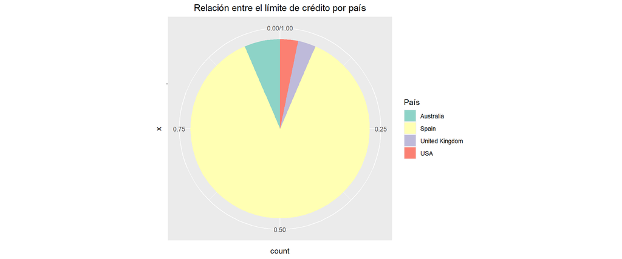

# Tercera Parte: Segmentación de Clientes

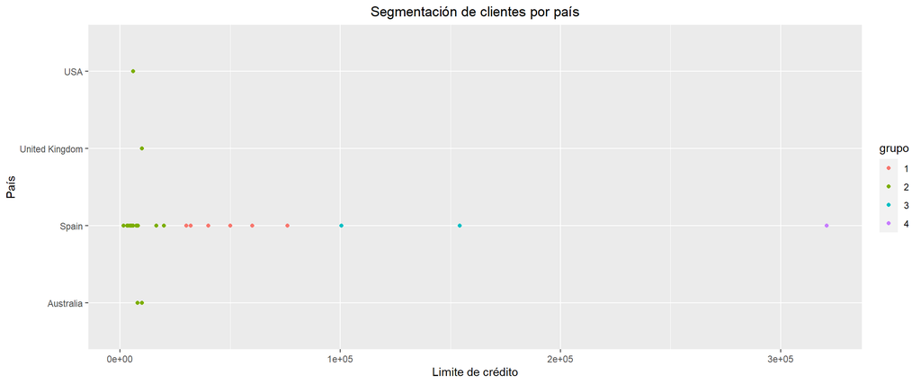

#Utilizaremos la función summary(kclust) para obtener un resumen de los resultados del algoritmo Kmeans.

```
##              Length Class  Mode
## cluster      31     -none- numeric
## centers      16     -none- numeric
## totss         1     -none- numeric
## withinss      4     -none- numeric
## tot.withinss  1     -none- numeric
## betweenss     1     -none- numeric
## size          4     -none- numeric
## iter          1     -none- numeric
## ifault        1     -none- numeric
```

# Cuarte Parte: Síntesis y Conclusiones

En este trabajo se exploró un dataset de una empresa de jardinería con el objetivo de analizar la relación entre el límite de crédito, el país y la región de los clientes. Se consideró que estas variables son relevantes para la empresa, ya que el límite de crédito determina cuánto crédito puede otorgar a cada cliente, y el país y la región pueden influir en las estrategias de marketing y ventas.

Se realizaron visualizaciones para analizar la relación entre el límite de crédito y la región, así como entre el límite de crédito y el país. Se observó que en algunas regiones y países los límites de crédito eran más altos que en otros, lo que indica diferencias en el poder adquisitivo de los clientes.

En conclusión, se encontró una relación entre el límite de crédito, el país y la región de los clientes de la empresa de jardinería. Estos hallazgos pueden ser útiles para adaptar las estrategias de marketing y ventas a cada contexto y mejorar la atención a los clientes.